# Geometric interpretation of NCI

Eric Marcon

21 June 2024

# 1 Neutral NCI

## 1.1 Definition

The crowding index of the neighbourhood of tree $i$ (called “focal tree”) is defined (Nemetschek et al. 2024) by

$${NCI}_i = \sum_j^{r_{i,j} \leq r_{max}}{d_j^2 / r_{i,j}}.$$

where the neighbours indexed by $j$ located at distance $r_{i,j}$ from the focal tree (less than $r_{max}$ fixed at 10m) have diameter $d_j$. Its dimension is a distance: $m^2 m^{-1}$.

## 1.2 Reformulation

$d_j / r_{i,j}$ is the tangent of the apparent angle $\alpha_j$ of the neighbour $j$ from the point of view of the focal tree. As the angles are small, the approximation $\alpha_j \approx \tan(\alpha_j)$ is valid.

The index can be rewritten
$${NCI}_i = \sum_j^{r_{i,j} \leq r_{max}}{d_j \alpha_j}.$$

The contribution of each neighbour is therefore the product of its apparent angle and its diameter.

There is no difference in the contribution to the crowding between a neighbour of diameter $d_j$ seen under the angle $\alpha_j$ and $n$ neighbours of the same diameter $d_j$ seen under the angle $\alpha_j / n$, for example because they are $n$ times further away.

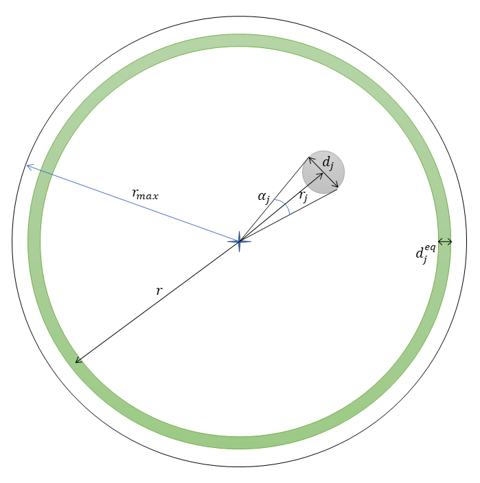

Figure 1.1: Equivalent diameter of neighbour $j$ for $\alpha = 2 \pi$.

We can define (figure 1.1) an equivalent diameter $d_j^{eq}$ for neighbour $j$ corresponding to an arbitrarily chosen apparent angle $\alpha$, which allows to characterize each neighbour by this single value such that

$${NCI}_i = \alpha \sum_j^{r_{i,j} \leq r_{max}}{d_j^{eq}}$$

where $d_j^{eq} = d_j \alpha_j / \alpha$.

The equivalent diameters of the neighbours are added together to define a total equivalent diameter of the neighbours of tree $i$:

$${NCI}_i = \alpha d_i^{eq}.$$

## 1.3 Interpretation

By choosing $\alpha = 2 \pi$, we see that each neighbour $j$ contributes to ${NCI}_i$ as if its apparent angle were the full circle and its diameter was $d_j^{eq} = d_j^2 / (2 \pi r_{i,j})$.

For any radius $r$ around the tree $i$, chosen arbitrarily with respect only to $r \gg d_i^{eq}$, $2 \pi r d_i^{eq}$ is the area of the ring of width $d_i^{eq}$ centred on $r$ (the difference in perimeter between the inside and outside of the ring is negligible, and the ring can be assimilated to a rectangle of length $2 \pi r$ and of width $d_i^{eq}$)

The crowding index divided by $2 \pi$, i.e. ${NCI}_i / (2\pi) = d_i^{eq}$, is therefore the width of a ring that completely encircles the focal tree $i$ at an arbitrary distance $r$.

Under the assumption of a completely random distribution of trees, $d_i^{eq}$, like ${NCI}_i$, is proportional to $r_{max}$. In other words, the farthest trees contribute less but are more numerous: their total contribution is equivalent to that of the closest trees. The most interesting metric is therefore
$${RCR}_i = d_i^{eq} / r_{max},$$
the proportion of the (one-dimensional) space crowded by neighbours, noted ${RCR}_i$ for *Radial Crowding Ratio*.

## 1.4 Edge effect correction

Focal trees whose distance to the edge of the observation window (i.e., forest plot boundaries) is less than $r_{max}$ are generally ignored because part of their neighbourhood is not observed, resulting in an underestimate of their crowding.

The correction of Ripley (1977) can be applied to estimate the unobserved value of the NCI. The contribution to the NCI of each neighbouring tree observed at distance $r_{i,j}$ is multiplied by a correction factor

$$\mathrm{c}_{i,j} = \frac{2 \pi r}{\mathrm{l}(\mathrm{C}(i, r_{i,j}) \cap W)}$$

where $\mathrm{l(\cdot)}$ is the length of the part of the circle $\mathrm{C}(i, r_{i,j})$ centred on the point $i$ and of radius $r_{i,j}$ with the observation window $W$.

Intuitively, each neighbour observed at a sufficiently large distance from the focal point so that a part of the circle on which it is located is outside the plot sees its contribution increased inversely proportionally to the part of the circle contained in the plot, as if as many neighbours existed in the unobserved part as in the observed part.

# 2 Application

## 2.1 Data

Paracou plot 6:

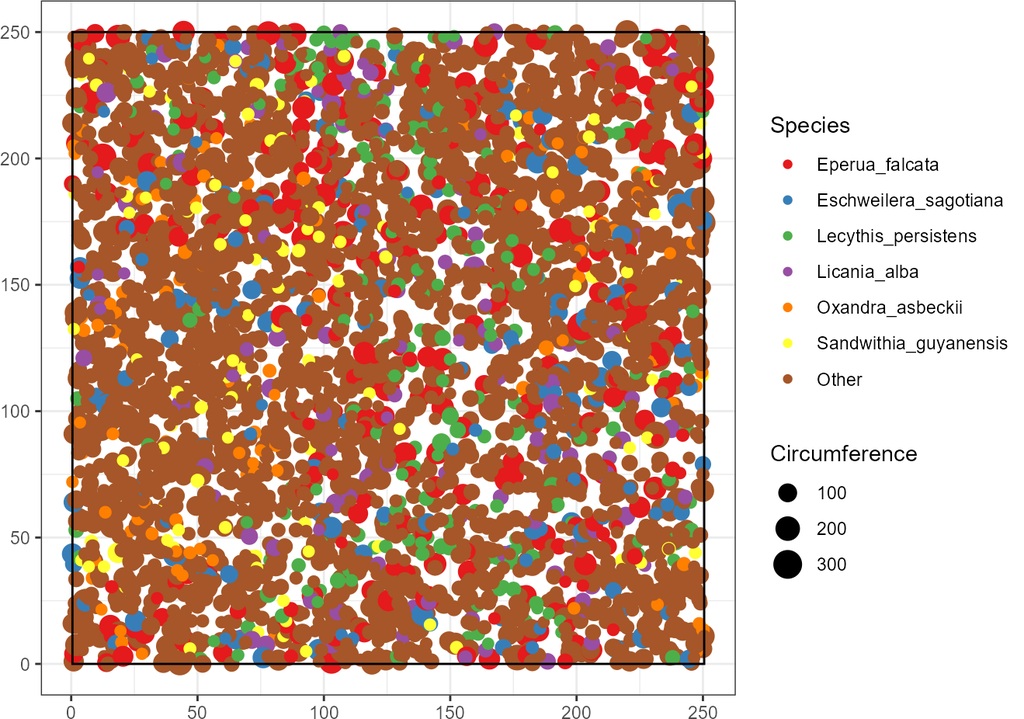

```r
library("tidyverse")
read_csv2("data/Paracou6.csv") ->
  paracou_6
# Map
library("dbmss")
paracou_6 %>%
  rename(X = Xfield, Y = Yfield, PointType = spName, PointWeight = CircCorr) %>%
  wmppp() %>%
  autoplot() +
  ggplot2::labs(col = "Species", size = "Circumference")
```

## 2.2 NCI calculation function

The `NCI()` function calculates the neutral crowding index around a focal tree.

```r
library("spatstat.geom")
library("cli")

#' NCI
#'
#' Calculate the NCI of point i
#'
#' @param data Paracou style dataframe.
#' Mandatory fields are idTree, Xfield, Yfield, CircCorr.
#' Contains a single measure campaign of a single plot.
#' @param plot_area The area (ha) of the plot that contains the data.
#' The plot is assumed to be square.
#' @param method The form of the NCI.
#' May be "inv" for inverse distance, "invsq" for inverse distance to the square or "exp" for exponential decay.
#' @param distance_min The minimum distance of neighbors from the focal tree.
#' Distances zero are forced to the minimum.
#' @param r_max The radius of the neighborhood.
#' @param u The decay rate of the exponential model: a negative value.
#' @param correct_edge_effects If `TRUE`, the Ripley correction of edge effects is applied,
#' else `NA` is returned for points too close to the edge of the window.
#'
#' @return The crowding index, in meters,
#' or `NA` if the point is too close to the edge of the window.
#'
NCI <- function(
    data,
    plot_area = 6.25,
    method = c("inv", "invsq", "exp"),
    distance_min = 0.25,
    r_max = 10,
    u = -0.25,
    correct_edge_effects = TRUE) {

  method <- match.arg(method)

  # Define the square window
  window_size <- 100 * sqrt(plot_area)
  the_window <- square(window_size, unitname = c("meter", "meters"))

  # Filter points inside the window
  data  %>%
    filter(Xfield >= 0 & Yfield >= 0 & Xfield <= window_size & Yfield <= window_size) ->
    data

  # Make a ppp
  the_ppp <- ppp(
    data$Xfield,
    data$Yfield,
    window = the_window
  )
  # id as mark
  marks(the_ppp) <- data.frame(
    id = data$idTree,
    diameter = data$CircCorr / pi / 100
  )

  # Compute NCI
  the_NCI <- numeric(the_ppp$n)
  cli_progress_bar("Computing neighborhoods", total = the_ppp$n)
  for (i in seq_len(the_ppp$n)) {
    # Neighborhood
    neighborhood <- the_ppp[disc(radius = r_max, centre = c(the_ppp$x[i], the_ppp$y[i]))]
    # Too close to the edge?
    is_too_close <- !is.subset.owin(neighborhood$window, the_ppp$window)
    if (is_too_close & !correct_edge_effects) {
      the_NCI[i] <- NA
      next
    }
    # Which is the center point?
    center_point <- which(neighborhood$marks$id == the_ppp$marks$id[i])
    # Distance from the center
    r_j <- pairdist(neighborhood)[, center_point]
    # Eliminate the center point
    r_j <- r_j[-center_point]
    # Set the minimum distance
    r_j <- pmax(r_j, distance_min)

    # Diameters
    d_j_squared <- neighborhood$marks$diameter^2
    # Eliminate the center point
    d_j_squared <- d_j_squared[-center_point]

    if (method == "inv") {
      # Normalized by distance
      NCI_i_neutral <- d_j_squared / r_j
    } else if (method == "invsq") {
      # Normalized by squared distance
      NCI_i_neutral <- d_j_squared / r_j^2
    } else if (method == "exp") {
      # Negative exponential
      NCI_i_neutral <- d_j_squared * exp(u * r_j)
    }
    # Edge effect correction
    if (is_too_close) {
      correction <- as.numeric(edge.Ripley(neighborhood[-center_point], r_j))
      NCI_i_neutral <- NCI_i_neutral * correction
    }
    # Sum neighbors
    the_NCI[i] <- sum(NCI_i_neutral)
    cli_progress_update()
  }
  cli_progress_done()
  return(the_NCI)
}
```

The `RCR()` function calculates the neutral crowding index of all trees of a plot.

```r
#' Relative Crowding Ratio
#'
#' @param ppp A planar point pattern.
#' @param distance_min The minimum distance of neighbors from the focal tree.
#' @param r_max The radius of the neighborhood.
#' @param correct_edge_effects If `TRUE`, the Ripley correction of edge effects is applied,
#' points too close to the edge of the window are eliminated.
#'
#' @return A vector of relative crowding ratios of all points of `ppp`.
#'
RCR <- function(
    data,
    plot_area = 6.25,
    method = c("inv", "invsq", "exp"),
    distance_min = 0.25,
    r_max = 10,
    u = -0.25,
    correct_edge_effects = TRUE) {

  # Compute NCI
  the_NCI <- NCI(
    data = data,
    plot_area = plot_area,
    method = method,
    distance_min = distance_min,
    r_max = r_max,
    u = u,
    correct_edge_effects = correct_edge_effects
  )
  # Crowding ratio
  return(the_NCI / 2 / pi / r_max)
}
```

## 2.3 Calculating the NCI of plot 6

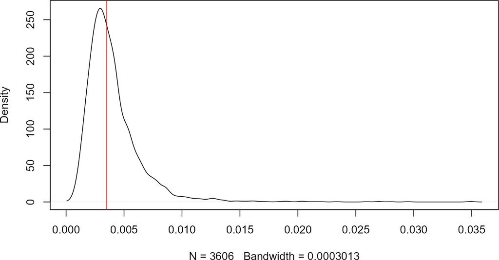

```r
# Compute RCR
paracou_6_RCR_10 <- RCR(paracou_6, r_max = 10)


# Distribution
RCR_median <- median(paracou_6_RCR_10, na.rm = TRUE)
library("GoFKernel")
plot(density.reflected(paracou_6_RCR_10, lower = 0, na.rm = TRUE), main = "")
abline(v = RCR_median, col = "red")
```

The median value of the crowding ratio is 3.5 per thousand.

## 2.4 Checking for distance sensitivity

By multiplying the neighbourhood radius by 2, NCI should be approximately multiplied by 2 and the crowding ratio should be stable. Increasing the radius eliminates points close to the edge of the plot and smoothes the neighbourhood data. The median is expected to be stable and the variability lower.

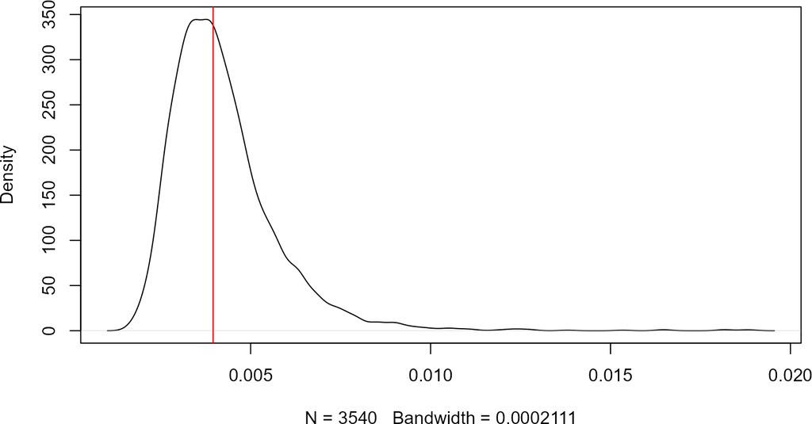

```r
# Compute crowding ratio
paracou_6_RCR_20 <- RCR(paracou_6, r_max = 20)

# Distribution
RCR_median_20 <- median(paracou_6_RCR_20, na.rm = TRUE)
plot(density.reflected(paracou_6_RCR_20, lower = 0, na.rm = TRUE), main = "")
abline(v = RCR_median_20, col = "red")
```

The median value of the crowding ratio is now 4 per thousand.

## 2.5 Conclusion

The RCR is used to interpret the crowding index. It is the width (normalised by the neighbourhood radius) of a ring around the focal point whose NCI is identical to the observed value. Its value is small: of the order of 3 to 4 per thousand.

Its definition is independent of the neighbourhood radius. Its value in plot 6 is very stable: at 60m (neighbourhood > 1ha), its median is 4.3 per thousand. The choice of radius does not therefore modify the average crowding index but its variability between trees.

# 3 Non neutral NCI

## 3.1 Definition

The crowding index of the neighbourhood of tree $i$ is defined (Nemetschek et al., n.d.) by
$${NCI}_i = \sum_j^{r_j \leq r_{max}}{\lambda_{i,j} d_j^2 / r_j},$$
where $\lambda_{i,j}$ is a weighting depending on the hypothesis being tested. For example, $\lambda_{i,j}$ can be the absolute difference between the values of a functional trait of the $j$ tree and the $i$ focal tree to take into account the proximity of niches of neighbours.

## 3.2 Geometric interpretation

The interpretation is similar to that of the neutral NCI.

For each neighbour, $d_j^{eq} = \lambda_j d_j \alpha_j / \alpha$. By choosing $\alpha = 2 \pi$, each neighbour $j$ contributes to ${NCI}_i$ as if its apparent angle were the full circle and its diameter were $d_j^{eq} = \lambda_j d_j^2 / (2 \pi r_j)$.

The definition ${RCR}_i = d_i^{eq} / r_{max}$ does not change. Just as $NCI_i$ can be negative, $d_i^{eq}$ and ${RCR}_i$ can be negative.

# 4 Alternative forms

## 4.1 Definitions

The NCI may be defined (Zambrano et al. 2020) as
$${NCI}_i = \sum_j^{r_{i,j} \leq r_{max}}{d_j^2 / r_{i,j}^2},$$

i.e. the squared diameters of neighbours are weighted by the inverse of their squared distance from the focal tree. The argument `method` of the `NCI()` function is “invsq” to apply this formula.

The exponential decay form (Schmitt, Hérault, and Derroire 2023) is
$${NCI}_i = \sum_j{d_j^2 e^{ur_{i,j}}},$$

where $u < 0$ is the decay rate, -0.25 by default in `NCI(method = "exp")`.

## 4.2 Comparing the methods

NCI’s are computed with max distance 10 or 20 meters, and with all three forms and no edge-effect correction.

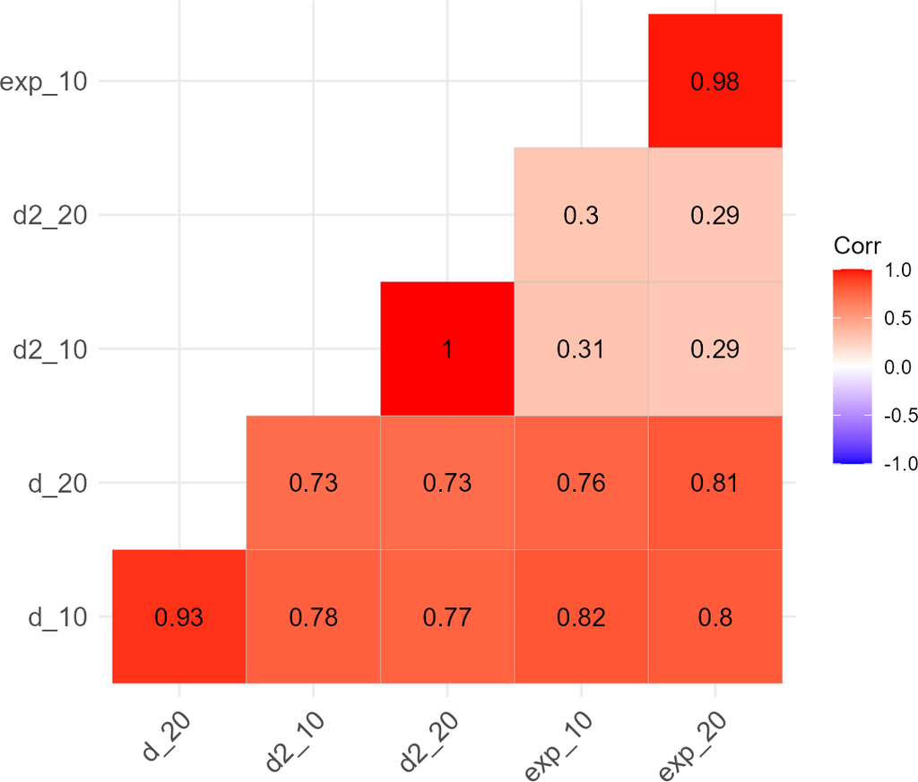

```r
# Compare the methods.
NCI_inv_10 <- NCI(paracou_6, method = "inv", correct_edge_effects = FALSE)
NCI_inv_20 <- NCI(paracou_6, method = "inv", r_max = 20, correct_edge_effects = FALSE)
NCI_invsq_10 <- NCI(paracou_6, method = "invsq", correct_edge_effects = FALSE)
NCI_invsq_20 <- NCI(paracou_6, method = "invsq", r_max = 20, correct_edge_effects = FALSE)
NCI_exp_10 <- NCI(paracou_6, method = "exp", correct_edge_effects = FALSE)
NCI_exp_20 <- NCI(paracou_6, method = "exp", r_max = 20, correct_edge_effects = FALSE)
# Correlogram
library("ggcorrplot")
data.frame(
  d_10 = NCI_inv_10,
  d_20 = NCI_inv_20,
  d2_10 = NCI_invsq_10,
  d2_20 = NCI_invsq_20,
  exp_10 = NCI_exp_10,
  exp_20 = NCI_exp_20
) %>%
  cor(use = "pairwise.complete.obs") %>%
  round(2) %>%
  ggcorrplot(type = "lower", lab = TRUE)
```

All NCIs are highly correlated, except for the squared distance and the exponential decays. The inverse distance method limited to 10 metres (d_10) is well correlated with all others, including the squared distance.

This can be illustrated by the curve of the factors, between 0.25 and 20 metres.

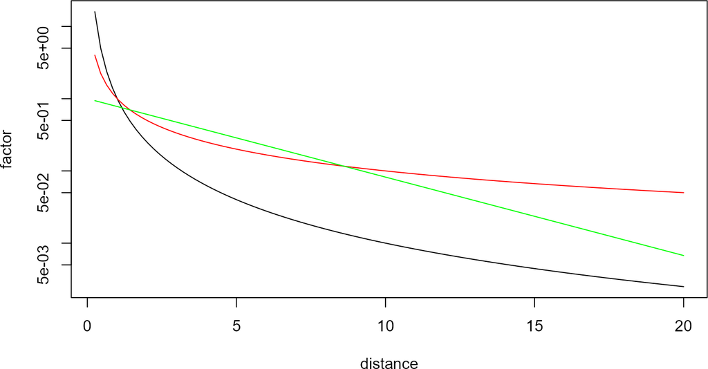

```r
d_max <- 20
curve(1/x^2, from = 0.25, to = d_max, log = "y", xlab = "distance", ylab = "factor")
curve(1/x, from = 0.25, to = d_max, add = TRUE, col = "red")
curve(exp(-.25 * x), from = .25, to = d_max, add = TRUE, col = "green")
```

The adavantage of the exponential decay form is that it does not define a sharp cut between neighbour and non-neighbour trees, but its decay rate is arbitrary. On the other hand, only the inverse-distance definition allows the geometric interpretation above.

# References

Nemetschek, Daniela, Géraldine Derroire, Eric Marcon, Mélaine Aubry-Kientz, Johanna Auer, Vincyane Badouard, Christopher Baraloto, et al. 2024. ‘Climate Anomalies and Neighbourhood Crowding Interact in Shaping Tree Growth in Old-Growth and Selectively Logged Tropical Forests’. *Journal of Ecology* 112 (January): 590–612. https://doi.org/10.1111/1365-2745.14256.

Nemetschek, Daniela, Claire Fortunel, Eric Marcon, Johanna Auer, Vincyane Badouard, Christopher Baraloto, Marion Boisseaux, et al. n.d. ‘Love Thy Neighbour? Tropical Tree Growth and Its Response to Climate Anomalies Is Mediated by Neighbourhood Hierarchy and Dissimilarity in Carbon and Water Related Traits.’ https://doi.org/10.22541/au.171366417.71658960/v1.

Ripley, Brian D. 1977. ‘Modelling Spatial Patterns’. *Journal of the Royal Statistical Society: Series B (Statistical Methodology)* 39 (2): 172–212.

Schmitt, Sylvain, Bruno Hérault, and Géraldine Derroire. 2023. ‘High Intraspecific Growth Variability Despite Strong Evolutionary Legacy in an Amazonian Forest’. *Ecology Letters* 26 (12): 2135–46. https://doi.org/10.1111/ele.14318.

Zambrano, Jenny, Noelle G. Beckman, Philippe Marchand, Jill Thompson, María Uriarte, Jess K. Zimmerman, María N. Umaña, and Nathan G. Swenson. 2020. ‘The Scale Dependency of Trait‐based Tree Neighborhood Models’. Edited by Leandro Duarte. *Journal of Vegetation Science* 31 (4): 581–93. https://doi.org/10.1111/jvs.12880.